# بنام خدا

Hossein Vatani

March 29, 2016

# تحلیل پراکنش(تحلیل واریانس) یکطرفه

اغلب اوقات ما در بررسی معنی داری تفاوت بین داده ها نیاز به بررسی میانگین بیش از دو دسته داده بایکدیگر داریم.جهت انجام آن باید از تحلیل پراکنش که در R با دستور aovنمایش داده می شوداستفاده نماییم.  
اگر تحلیل پراکنش(یا همان آزمون فیشر) مشخص کرد که بین میانگین داده ها تفاوت معنی داری وجود دارد، باید با بررسی هایی دیگر مشخص شود که کدامیک از داده ها باهم تفاوت معنی دار دارند.

## الف- تحلیل پراکنش

اولین گام در تحلیل پراکنش، بررسی تصویری میانگین متغیرها مورد نظر در قبال سایر داده هاست.برای ایم امر لازم است که نمودار جعبه ای آنها را پیاده سازی کنیم و این موضوع بسادگی با دستور زیر امکانپذیر است.

```r
plot(response ~ factor, data=data_name)
```

که

```
response=متغیر پاسخ یا همان مورد نظر جهت بررسی است
factor=متغیری که داده ها با توجه به آن دسته بندی می شوند
data_name=مجموعه داده ای مورد نظر
```

مثال-یک شرکت تولید دارو، سه داروی مسکن برای بیماران مبتلا به سردرد میگرن را برروی ۲۷ داوطلب که بطور تصادفی به سه گروه نه نفره تقسیم شده بودند، آزمایش کرد.به هر گروه داروی مربوطه داده شد و قرار شد در سردرد بعدی آنرا مصرف کرده و سپس شدت درد را با عددی بین ۰-۱۰ گزارش نماییند که نتیجه بشرح زیر شد.

```
DrugA   4 5 4 3 2 4 3 4 4
DrugB   6 8 4 5 4 6 5 8 6
DrugC   6 7 6 6 7 5 6 5 5
```

آزمون فرض را اینگ.نه تعریف می کنیم: $\mu_1 \rightarrow mean(Drug A),\mu_2 \rightarrow mean(Drug B),\mu_3 \rightarrow mean(Drug C) \Rightarrow \begin{cases} H_0: \mu_1=\mu_2=\mu_3 \\ H_1: \exists i,j\text{ }in\text{ }{1,2,3}\text{ }\Rightarrow\text{ }\mu_i \neq \mu_j \\ \end{cases}$

جهت نمایش تصویری، ابتدا لازم است که داده ها را بصورت قاب-داده در نرم افزار وارد کنیم.

```r
pain = c(4, 5, 4, 3, 2, 4, 3, 4, 4, 6, 8, 4, 5, 4, 6, 5, 8, 6, 6, 7, 6, 6, 7, 5, 6, 5, 5)
drug = c(rep("A",9), rep("B",9), rep("C",9))
migraine = data.frame(pain,drug)
migraine
```

```
##    pain drug
## 1     4    A
## 2     5    A
## 3     4    A
## 4     3    A
## 5     2    A
## 6     4    A
## 7     3    A
## 8     4    A
## 9     4    A
## 10    6    B
## 11    8    B
## 12    4    B
## 13    5    B
## 14    4    B
## 15    6    B
## 16    5    B
## 17    8    B
## 18    6    B
## 19    6    C
## 20    7    C
## 21    6    C
## 22    6    C
## 23    7    C
## 24    5    C
## 25    6    C
## 26    5    C
## 27    5    C
```

جهت نمایش جعبه ای میزان درد در هر گروه

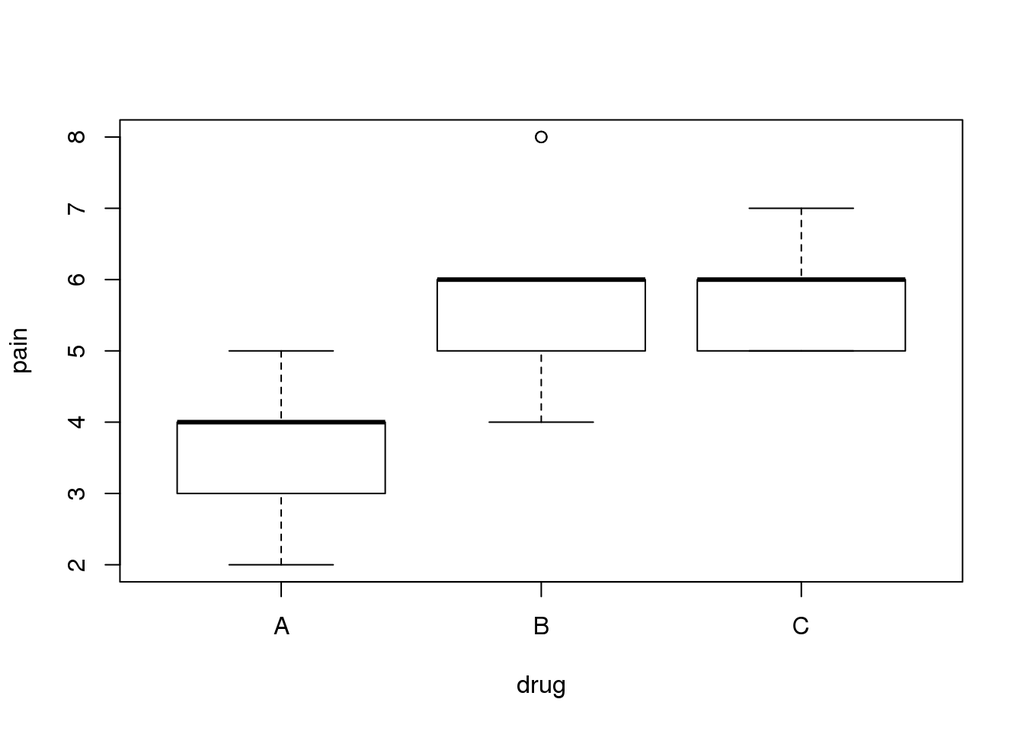

```r
plot(pain~drug, data = migraine)
```

همانطور که از تصویر نمایان است میانگین تاثیر داروی A از دو داروی دیگر کمتر و همچنین میانگین دو داروی B و C با توجه به تصویر تقریبا برابر است.

در مرحله بعد با استفاده از تابع ()aov به تحلیل موضوع (در واقع همان بررسی شرط آزمون) خواهیم پرداخت پرداخت. رابطه کلی آن بدین صورت است

```r
aov(response ~ factor, data=data_name)
```

که توضیحات عاملهای آن مانند عاملهای نمایش-جعبه ایست.نتیجه این آزمون یک شیئ از نوع لیست(List) می باشد که با دستور ()summary می توان تعداد قابل توجهی از اطلاعات مفید آن را ملاحظه کرد.

```r
fit = aov(pain ~ drug, data=migraine)
summary(fit)
```

```
##             Df Sum Sq Mean Sq F value   Pr(>F)
## drug         2  28.22  14.111   11.91 0.000256 ***
## Residuals   24  28.44   1.185
## ---
## Signif. codes:  0 '***' 0.001 '**' 0.01 '*' 0.05 '.' 0.1 ' ' 1
```

مقدار p-value این آزمون فیشر به ما می گوید که بطور قطع فرض صفر رد می شود.

## ب-مقایسه چندگانه

تحلیل پراکنش آزمون فیشر،برای تحلیلگر مشخص می کند که آیا بین عاملها تفاوت معنی داری وجود دارد یا خیر اما همانطور که گفته شد، ابزار تشخیص که کدام عاملها با یکدیگر تفاوت دارند را در اختیار نمی گذارد.همانطور که مستحضر هستید آزمون هایی دیگر بانام پس-از-آزمون(add-hoc) وجود دارد.

برای مثال قبل که مقایسه برای گروه های یک مجموعه از داده می باشد آزمون ()pairwise.t.test بکار می رود.رابطه کلی آن

```r
pairwise.t.test(reponse, factor, p.adjust = method, alternative = c("two.sided","less","greater"))
```

می باشد که عامل های اول و دوم و چهارم توضیح داده شده است

```
p.adjust= نوع های متفاوتی وجود دارد که می توان به "benferroni","holm","hochberg","hommel","BH","BY" اشاره کرد
```

برای مثال قبل داریم:

```r
pairwise.t.test(pain, drug, p.adjust="bonferroni")
```

```
##
##  Pairwise comparisons using t tests with pooled SD
##
## data:  pain and drug
##
##   A       B
## B 0.00119 -
## C 0.00068 1.00000
##
## P value adjustment method: bonferroni
```

که همانطور که از نتیجه مشخص است، بین مقادیر داروی A با هر دو نوع داروی B و C اختلاف معنی دار وجود دارد که این مورد بین B و C وجود ندارد.لذا فرض $H_1$بدین صورت قابل اعلام است: $H_1:\mu_1 \neq \mu_2=\mu_3$

آزمون دیگری که قابل استفاده است آزمون Tukey می باشد که رابطه آن بشرخ زیر است

```r
TukeyHSD(fit, conf.level = 0.95)
```

که

```
fit=نتیجه تحلیل پراکنش (که همان شیئ لیست حاصل از دستور aov می باشد).
conf.level= سطح اطمینان مورد نظر
```

مجددا مثال قبل را بررسی می کنیم.

```r
TukeyHSD(fit, conf.level = 0.95)
```

```
##   Tukey multiple comparisons of means
##     95% family-wise confidence level
##
## Fit: aov(formula = pain ~ drug, data = migraine)
##
## $drug
##          diff        lwr      upr     p adj
## B-A 2.1111111  0.8295028 3.392719 0.0011107
## C-A 2.2222222  0.9406139 3.503831 0.0006453
## C-B 0.1111111 -1.1704972 1.392719 0.9745173
```